# CS 8321 Final Project

## Francesco Trozzi (47779944) - George Sammit (04010135) - Megan Simons (46334773)

```python
import keras
import matplotlib.pyplot as plt
import seaborn as sns
import pandas as pd
import numpy as np
from tensorflow.keras.utils import plot_model
```

```python
import numpy as np
import seaborn as sns
import pandas as pd
from tensorflow.keras.models import load_model
from scipy.stats import describe
```

# Architectures

Multiple architectures were investigated in this study. All of them shared the same goal of creating the same plausible protein structure output which would minimize the loss, regardless of the specific conformation used. Besides visualizing the outputs, different analyses were performed that confirmed this behaviour. In order to fix this problem, we created and tweaked multiple architectures. Some representatives are listed below.

### M1 - Model architecture

In this study we aimed to build a multi-modal network that from structural features would be able to reconstruct the Cartesian coordinates of the protein. The goal would be then to investigate the latent space, which would have encoded the conformational space of the protein. We further implemented a new convolutional scheme to directly feed local and global information to the latent space. Our goal was to have a latent space that explicitly has both types of information, but not affected by the loss of resolution caused by pooling. It should have information about communities of atoms (formed after pooling) as well.

```python
# There are 148 residues in the protein, each element of the squared matrix is the distance between two residues
input_arr = keras.Input(shape=(148, 148, 1))
conv1 = keras.layers.Conv2D(filters=32, kernel_size=(3, 3), padding='same', input_shape=(148, 148, 1), kernel_initializer='he_uniform', activation='relu', data_format="channels_last", kernel_regularizer=keras.regularizers.l2(0.01))(input_arr)
conv1 = keras.layers.Conv2D(filters=32, kernel_size=(3, 3), padding='same', kernel_initializer='he_uniform', activation='relu', data_format="channels_last", kernel_regularizer=keras.regularizers.l2(0.01))(conv1)
flat1 = keras.layers.Flatten()(conv1)
max1 = keras.layers.AveragePooling2D(pool_size=(2, 2), padding='same', data_format="channels_last" )(input_arr)

# We reduced the input space before it is convoluted to obtain a coarser version of the original input
conv2 = keras.layers.Conv2D(filters=64, kernel_size= (3, 3), padding='same', kernel_initializer='he_uniform', activation='relu', data_format="channels_last", kernel_regularizer=keras.regularizers.l2(0.01))(max1)
conv2 = keras.layers.Conv2D(filters=64, kernel_size= (3, 3), padding='same', kernel_initializer='he_uniform', activation='relu', data_format="channels_last", kernel_regularizer=keras.regularizers.l2(0.01))(conv2)
flat2 = keras.layers.Flatten()(conv2)
max2 = keras.layers.AveragePooling2D(pool_size=(2, 2), padding='same', data_format="channels_last" )(max1)

# We reduced the input space before it is convoluted to obtain a coarser version of the original input
conv3 = keras.layers.Conv2D(filters=128, kernel_size= (3, 3), padding='same', kernel_initializer='he_uniform', activation='relu', data_format="channels_last", kernel_regularizer=keras.regularizers.l2(0.01))(max2)
conv3 = keras.layers.Conv2D(filters=128, kernel_size= (3, 3), padding='same', kernel_initializer='he_uniform', activation='relu', data_format="channels_last", kernel_regularizer=keras.regularizers.l2(0.01))(conv3)
flat3 = keras.layers.Flatten()(conv3)
max3 = keras.layers.AveragePooling2D(pool_size=(2, 2), padding='same', data_format="channels_last" )(max2)

# We reduced the input space before it is convoluted to obtain a coarser version of the original input
conv4 = keras.layers.Conv2D(filters=256, kernel_size= (3, 3), padding='same', kernel_initializer='he_uniform', activation='relu', data_format="channels_last", kernel_regularizer=keras.regularizers.l2(0.01))(max3)
conv4 = keras.layers.Conv2D(filters=256, kernel_size= (3, 3), padding='same', kernel_initializer='he_uniform', activation='relu', data_format="channels_last", kernel_regularizer=keras.regularizers.l2(0.01))(conv4)
flat4 = keras.layers.Flatten()(conv4)
max4 = keras.layers.AveragePooling2D(pool_size=(2, 2), padding='same', data_format="channels_last" )(max3)

# We performed this operation unti we reach the number of secondary structures in the protein (here we analyze distances between sec structure elements)
conv5 = keras.layers.Conv2D(filters=256, kernel_size= (3, 3), padding='same', kernel_initializer='he_uniform', activation='relu', data_format="channels_last", kernel_regularizer=keras.regularizers.l2(0.01))(max4)
conv5 = keras.layers.Conv2D(filters=256, kernel_size= (3, 3), padding='same', kernel_initializer='he_uniform', activation='relu', data_format="channels_last", kernel_regularizer=keras.regularizers.l2(0.01))(conv5)
flat5 = keras.layers.Flatten()(conv5)

# After the convolutions we provide the flattened outputs to the latent space
x = keras.layers.Concatenate()([flat1, flat2, flat3, flat4, flat5])
latent = keras.layers.Dense(32, activation='relu', kernel_initializer='he_uniform', kernel_regularizer=keras.regularizers.l1(0.00001))(x) # l1 regularization is done to have a sparse latent space which has to decide which features are inportant
latent = keras.layers.Dropout(0.3)(latent)

# Dense decoder which has to build the protein structure for latent space
decoded = keras.layers.Dense(64, activation='relu', kernel_regularizer=keras.regularizers.l2(0.01))(latent)
decoded = keras.layers.Dropout(0.3)(decoded)
decoded = keras.layers.Dense(128, activation='relu', kernel_regularizer=keras.regularizers.l2(0.01))(decoded)
decoded = keras.layers.Dropout(0.3)(decoded)
decoded = keras.layers.Dense(256, activation='relu', kernel_regularizer=keras.regularizers.l2(0.01))(decoded)
decoded = keras.layers.Dropout(0.3)(decoded)
decoded = keras.layers.Dense(444, activation='relu')(decoded)


# Total model
autoencoder = keras.Model(input_arr, decoded)
plot_model(autoencoder, show_shapes=True, show_layer_names=True)
```

```
Failed to import pydot. You must install pydot and graphviz for `pydotprint` to work.
```

### M2 - First improvement

We noticed that 5 independent convolutional blocks might provide too much information to the latent space which could make learning more difficult. For this reson, we reduced the number of convolution blocks (while retaining the same end point of nxn matrix where n is the number of secondary structures) by incrementing the pool_size. Furthermore, since the convolutional blocks are parallel (independent) there is no reason to increment the number of filters down the road as we do not expect the level of abstraction to increase from one block to the other.

```python
input_arr = keras.Input(shape=(148, 148, 1))
conv1 = keras.layers.Conv2D(filters=32, kernel_size=(4, 4), padding='same', input_shape=(148, 148, 1), kernel_initializer='he_uniform', activation='relu', data_format="channels_last", kernel_regularizer=keras.regularizers.l2(0.01))(input_arr)
conv1 = keras.layers.Conv2D(filters=32, kernel_size=(4, 4), padding='same', kernel_initializer='he_uniform', activation='relu', data_format="channels_last", kernel_regularizer=keras.regularizers.l2(0.01))(conv1)
flat1 = keras.layers.Flatten()(conv1)
max1 = keras.layers.AveragePooling2D(pool_size=(4, 4), padding='same', data_format="channels_last" )(input_arr)

# 36 x 36
conv2 = keras.layers.Conv2D(filters=32, kernel_size= (4, 4), padding='same', kernel_initializer='he_uniform', activation='relu', data_format="channels_last", kernel_regularizer=keras.regularizers.l2(0.01))(max1)
conv2 = keras.layers.Conv2D(filters=32, kernel_size= (4, 4), padding='same', kernel_initializer='he_uniform', activation='relu', data_format="channels_last", kernel_regularizer=keras.regularizers.l2(0.01))(conv2)
flat2 = keras.layers.Flatten()(conv2)
max2 = keras.layers.AveragePooling2D(pool_size=(4, 4), padding='same', data_format="channels_last" )(max1)

# 9 x 9
conv3 = keras.layers.Conv2D(filters=32, kernel_size= (2, 2), padding='same', kernel_initializer='he_uniform', activation='relu', data_format="channels_last", kernel_regularizer=keras.regularizers.l2(0.01))(max2)
conv3 = keras.layers.Conv2D(filters=32, kernel_size= (2, 2), padding='same', kernel_initializer='he_uniform', activation='relu', data_format="channels_last", kernel_regularizer=keras.regularizers.l2(0.01))(conv3)
flat3 = keras.layers.Flatten()(conv3)

x = keras.layers.Concatenate()([flat1, flat2, flat3])
latent = keras.layers.Dense(32, activation='relu', kernel_initializer='he_uniform', kernel_regularizer=keras.regularizers.l1(0.00001))(x)
latent = keras.layers.Dropout(0.3)(latent)

decoded = keras.layers.Dense(64, activation='relu', kernel_regularizer=keras.regularizers.l2(0.01))(latent)
decoded = keras.layers.Dropout(0.3)(decoded)
decoded = keras.layers.Dense(128, activation='relu', kernel_regularizer=keras.regularizers.l2(0.01))(decoded)
decoded = keras.layers.Dropout(0.3)(decoded)
decoded = keras.layers.Dense(256, activation='relu', kernel_regularizer=keras.regularizers.l2(0.01))(decoded)
decoded = keras.layers.Dropout(0.3)(decoded)
decoded = keras.layers.Dense(444, activation='relu')(decoded)


# Total model
autoencoder = keras.Model(input_arr, decoded)
plot_model(autoencoder, show_shapes=True, show_layer_names=True)
```

### M3 - Second improvement

We still noticed that the latent space was performing a one-size-fits-all output. We thought that reducing the number of blocks and filters would help, but the resulting latent space was still too big to be approximated to 32 (neurons) dimensions without first having some pre-processing. For this reason, we expanded the latent space into its own funnel-like architecture, giving the ability to process such high-dimensional input. In the reconstructed structures output by this model we noticed that some atoms were misplaced. We noticed this artifact in the Lab 3, where we used solely dense networks. This tells us that too many dense layers in the latent space could be counterproductive. The problem of the same output still remains.

```python
input_arr = keras.Input(shape=(148, 148, 1))
conv1 = keras.layers.Conv2D(filters=32, kernel_size=(4, 4), padding='same', input_shape=(148, 148, 1), kernel_initializer='he_uniform', activation='relu', data_format="channels_last", kernel_regularizer=keras.regularizers.l2(0.01))(input_arr)
conv1 = keras.layers.Conv2D(filters=32, kernel_size=(4, 4), padding='same', kernel_initializer='he_uniform', activation='relu', data_format="channels_last", kernel_regularizer=keras.regularizers.l2(0.01))(conv1)
flat1 = keras.layers.Flatten()(conv1)
max1 = keras.layers.AveragePooling2D(pool_size=(4, 4), padding='same', data_format="channels_last" )(input_arr)

# 36 x 36
conv2 = keras.layers.Conv2D(filters=32, kernel_size= (4, 4), padding='same', kernel_initializer='he_uniform', activation='relu', data_format="channels_last", kernel_regularizer=keras.regularizers.l2(0.01))(max1)
conv2 = keras.layers.Conv2D(filters=32, kernel_size= (4, 4), padding='same', kernel_initializer='he_uniform', activation='relu', data_format="channels_last", kernel_regularizer=keras.regularizers.l2(0.01))(conv2)
flat2 = keras.layers.Flatten()(conv2)
max2 = keras.layers.AveragePooling2D(pool_size=(4, 4), padding='same', data_format="channels_last" )(max1)

# 9 x 9
conv3 = keras.layers.Conv2D(filters=32, kernel_size= (2, 2), padding='same', kernel_initializer='he_uniform', activation='relu', data_format="channels_last", kernel_regularizer=keras.regularizers.l2(0.01))(max2)
conv3 = keras.layers.Conv2D(filters=32, kernel_size= (2, 2), padding='same', kernel_initializer='he_uniform', activation='relu', data_format="channels_last", kernel_regularizer=keras.regularizers.l2(0.01))(conv3)
flat3 = keras.layers.Flatten()(conv3)

x = keras.layers.Concatenate()([flat1, flat2, flat3])
latent = keras.layers.Dense(1024, activation='relu', kernel_initializer='he_uniform', kernel_regularizer=keras.regularizers.l2(0.01))(x)
latent = keras.layers.Dropout(0.3)(latent)
latent = keras.layers.Dense(512, activation='relu', kernel_initializer='he_uniform', kernel_regularizer=keras.regularizers.l2(0.01))(x)
latent = keras.layers.Dropout(0.3)(latent)
latent = keras.layers.Dense(128, activation='relu', kernel_initializer='he_uniform', kernel_regularizer=keras.regularizers.l2(0.01))(latent)
latent = keras.layers.Dropout(0.3)(latent)
latent = keras.layers.Dense(32, activation='relu', kernel_initializer='he_uniform', kernel_regularizer=keras.regularizers.l1(0.00001))(latent)
latent = keras.layers.Dropout(0.3)(latent)

decoded = keras.layers.Dense(64, activation='relu', kernel_regularizer=keras.regularizers.l2(0.01))(latent)
decoded = keras.layers.Dropout(0.3)(decoded)
decoded = keras.layers.Dense(128, activation='relu', kernel_regularizer=keras.regularizers.l2(0.01))(decoded)
decoded = keras.layers.Dropout(0.3)(decoded)
decoded = keras.layers.Dense(256, activation='relu', kernel_regularizer=keras.regularizers.l2(0.01))(decoded)
decoded = keras.layers.Dropout(0.3)(decoded)
decoded = keras.layers.Dense(444, activation='relu')(decoded)


# Total model
autoencoder = keras.Model(input_arr, decoded)
plot_model(autoencoder, show_shapes=True, show_layer_names=True)
```

### M4 - Third improvement

Given the above problem we decided to reduce the depth of the dense layers with the goal of having a less dense latent space and less dense decoder. Spoiler, it didn't help.

```python
input_arr = keras.Input(shape=(148, 148, 1))
conv1 = keras.layers.Conv2D(filters=32, kernel_size=(4, 4), padding='same', input_shape=(148, 148, 1), kernel_initializer='he_uniform', activation='relu', data_format="channels_last", kernel_regularizer=keras.regularizers.l2(0.01))(input_arr)
conv1 = keras.layers.Conv2D(filters=32, kernel_size=(4, 4), padding='same', kernel_initializer='he_uniform', activation='relu', data_format="channels_last", kernel_regularizer=keras.regularizers.l2(0.01))(conv1)
flat1 = keras.layers.Flatten()(conv1)
max1 = keras.layers.AveragePooling2D(pool_size=(4, 4), padding='same', data_format="channels_last" )(input_arr)

# 36 x 36
conv2 = keras.layers.Conv2D(filters=32, kernel_size= (4, 4), padding='same', kernel_initializer='he_uniform', activation='relu', data_format="channels_last", kernel_regularizer=keras.regularizers.l2(0.01))(max1)
conv2 = keras.layers.Conv2D(filters=32, kernel_size= (4, 4), padding='same', kernel_initializer='he_uniform', activation='relu', data_format="channels_last", kernel_regularizer=keras.regularizers.l2(0.01))(conv2)
flat2 = keras.layers.Flatten()(conv2)
max2 = keras.layers.AveragePooling2D(pool_size=(4, 4), padding='same', data_format="channels_last" )(max1)

# 9 x 9
conv3 = keras.layers.Conv2D(filters=32, kernel_size= (2, 2), padding='same', kernel_initializer='he_uniform', activation='relu', data_format="channels_last", kernel_regularizer=keras.regularizers.l2(0.01))(max2)
conv3 = keras.layers.Conv2D(filters=32, kernel_size= (2, 2), padding='same', kernel_initializer='he_uniform', activation='relu', data_format="channels_last", kernel_regularizer=keras.regularizers.l2(0.01))(conv3)
flat3 = keras.layers.Flatten()(conv3)

# Shallow latent space
x = keras.layers.Concatenate()([flat1, flat2, flat3])
latent = keras.layers.Dense(32, activation='relu', kernel_initializer='he_uniform', kernel_regularizer=keras.regularizers.l1(0.00001))(x)
latent = keras.layers.Dropout(0.3)(latent)

# Shallow decoder
decoded = keras.layers.Dense(128, activation='relu', kernel_regularizer=keras.regularizers.l2(0.01))(latent)
decoded = keras.layers.Dropout(0.3)(decoded)
decoded = keras.layers.Dense(444, activation='relu')(decoded)


# Total model
autoencoder = keras.Model(input_arr, decoded)
plot_model(autoencoder, show_shapes=True, show_layer_names=True)
```

## Network alternatives

At this point we thought that the problem could be arising from our convolutional scheme. By getting rid of this, it would mean not giving explicit local and global structural information simultaneously. It would be difficult to retrieve those separately when checking which part of the input space would be more influential. Therefore, we tried to implement simple convolutional networks (with and without pooling) to check if our scheme was the issue. Furthermore we tried with a pure dense network as well. In fact in lab 3, where we used another protein, we did not encounter the same issue.

### M5- Full convolution no pooling

```python
input_arr = keras.Input(shape=(148, 148, 1))
encoded = keras.layers.Conv2D(filters=32, kernel_size=(3, 3), padding='same', input_shape=(148, 148, 1), kernel_initializer='he_uniform', activation='relu', data_format="channels_last", kernel_regularizer=keras.regularizers.l2(0.01))(input_arr)
encoded = keras.layers.Conv2D(filters=32, kernel_size=(3, 3), padding='same', kernel_initializer='he_uniform', activation='relu', data_format="channels_last", kernel_regularizer=keras.regularizers.l2(0.01))(encoded)
encoded = keras.layers.Conv2D(filters=64, kernel_size=(3, 3), padding='same', kernel_initializer='he_uniform', activation='relu', data_format="channels_last", kernel_regularizer=keras.regularizers.l2(0.01))(encoded)
encoded = keras.layers.Conv2D(filters=64, kernel_size=(3, 3), padding='same', kernel_initializer='he_uniform', activation='relu', data_format="channels_last", kernel_regularizer=keras.regularizers.l2(0.01))(encoded)
encoded = keras.layers.Conv2D(filters=128, kernel_size=(3, 3), padding='same', kernel_initializer='he_uniform', activation='relu', data_format="channels_last", kernel_regularizer=keras.regularizers.l2(0.01))(encoded)
encoded = keras.layers.Conv2D(filters=128, kernel_size=(3, 3), padding='same', kernel_initializer='he_uniform', activation='relu', data_format="channels_last", kernel_regularizer=keras.regularizers.l2(0.01))(encoded)

latent = keras.layers.Flatten()(encoded)
latent = keras.layers.Dense(128, activation='relu', kernel_initializer='he_uniform', kernel_regularizer=keras.regularizers.l2(0.01))(latent)
latent = keras.layers.Dropout(0.2)(latent)
latent = keras.layers.Dense(64, activation='relu', kernel_initializer='he_uniform', kernel_regularizer=keras.regularizers.l2(0.01))(latent)

decoded = keras.layers.Dense(64, activation='relu', kernel_regularizer=keras.regularizers.l2(0.01))(latent)
decoded = keras.layers.Dropout(0.2)(decoded)
decoded = keras.layers.Dense(128, activation='relu', kernel_regularizer=keras.regularizers.l2(0.01))(decoded)
idecoded = keras.layers.Dropout(0.2)(decoded)
decoded = keras.layers.Dense(256, activation='relu', kernel_regularizer=keras.regularizers.l2(0.01))(decoded)
decoded = keras.layers.Dropout(0.2)(decoded)
decoded = keras.layers.Dense(444, activation='relu', kernel_regularizer=keras.regularizers.l2(0.01))(decoded)


# Total model
autoencoder = keras.Model(input_arr, decoded)
plot_model(autoencoder, show_shapes=True, show_layer_names=True)
```

### M6 - Full convolution with pooling

```python
input_arr = keras.Input(shape=(148, 148, 1))
encoded = keras.layers.Conv2D(filters=32, kernel_size=(3, 3), padding='same', input_shape=(148, 148, 1), kernel_initializer='he_uniform', activation='relu', data_format="channels_last", kernel_regularizer=keras.regularizers.l2(0.01))(input_arr)
encoded = keras.layers.Conv2D(filters=32, kernel_size=(3, 3), padding='same', kernel_initializer='he_uniform', activation='relu', data_format="channels_last", kernel_regularizer=keras.regularizers.l2(0.01))(encoded)
encoded = keras.layers.MaxPooling2D(pool_size=(2, 2), padding='same', data_format="channels_last" )(encoded)
encoded = keras.layers.Conv2D(filters=64, kernel_size= (3, 3), padding='same', kernel_initializer='he_uniform', activation='relu', data_format="channels_last", kernel_regularizer=keras.regularizers.l2(0.01))(encoded)
encoded = keras.layers.Conv2D(filters=64, kernel_size= (3, 3), padding='same', kernel_initializer='he_uniform', activation='relu', data_format="channels_last", kernel_regularizer=keras.regularizers.l2(0.01))(encoded)
encoded = keras.layers.MaxPooling2D(pool_size=(2, 2), padding='same', data_format="channels_last" )(encoded)
encoded = keras.layers.Conv2D(filters=128, kernel_size= (3, 3), padding='same', kernel_initializer='he_uniform', activation='relu', data_format="channels_last", kernel_regularizer=keras.regularizers.l2(0.01))(encoded)
encoded = keras.layers.Conv2D(filters=128, kernel_size= (3, 3), padding='same', kernel_initializer='he_uniform', activation='relu', data_format="channels_last", kernel_regularizer=keras.regularizers.l2(0.01))(encoded)
encoded = keras.layers.MaxPooling2D(pool_size=(2, 2), padding='same', data_format="channels_last" )(encoded)
encoded = keras.layers.Conv2D(filters=256, kernel_size= (3, 3), padding='same', kernel_initializer='he_uniform', activation='relu', data_format="channels_last", kernel_regularizer=keras.regularizers.l2(0.01))(encoded)
encoded = keras.layers.Conv2D(filters=256, kernel_size= (3, 3), padding='same', kernel_initializer='he_uniform', activation='relu', data_format="channels_last", kernel_regularizer=keras.regularizers.l2(0.01))(encoded)

latent = keras.layers.Flatten()(encoded)
latent = keras.layers.Dense(128, activation='relu', kernel_initializer='he_uniform', kernel_regularizer=keras.regularizers.l2(0.01))(latent)
latent = keras.layers.Dropout(0.2)(latent)
latent = keras.layers.Dense(64, activation='relu', kernel_initializer='he_uniform', kernel_regularizer=keras.regularizers.l2(0.01))(latent)

decoded = keras.layers.Dense(64, activation='relu', kernel_regularizer=keras.regularizers.l2(0.01))(latent)
decoded = keras.layers.Dropout(0.2)(decoded)
decoded = keras.layers.Dense(128, activation='relu', kernel_regularizer=keras.regularizers.l2(0.01))(decoded)
decoded = keras.layers.Dropout(0.2)(decoded)
decoded = keras.layers.Dense(256, activation='relu', kernel_regularizer=keras.regularizers.l2(0.01))(decoded)
decoded = keras.layers.Dropout(0.2)(decoded)
decoded = keras.layers.Dense(444, activation='relu', kernel_regularizer=keras.regularizers.l2(0.01))(decoded)

# Total model
autoencoder = keras.Model(input_arr, decoded)
plot_model(autoencoder, show_shapes=True, show_layer_names=True)
```

### M7 - Dense

```python
input_arr = keras.Input(shape=(10585,))
encoded = keras.layers.Dense(10585, activation='relu')(input_arr)
encoded = keras.layers.Dropout(0.2)(encoded)
encoded = keras.layers.Dense(1024, activation='relu')(encoded)
encoded = keras.layers.Dropout(0.2)(encoded)
encoded = keras.layers.Dense(512, activation='relu')(encoded)
encoded = keras.layers.Dropout(0.2)(encoded)
encoded = keras.layers.Dense(256, activation='relu')(encoded)
encoded = keras.layers.Dropout(0.2)(encoded)
encoded = keras.layers.Dense(128, activation='relu')(encoded)
encoded = keras.layers.Dropout(0.2)(encoded)
encoded = keras.layers.Dense(64, activation='relu', activity_regularizer= keras.regularizers.l1(10e-5))(encoded)

decoded = keras.layers.Dense(64, activation='relu')(encoded)
decoded = keras.layers.Dropout(0.2)(decoded)
decoded = keras.layers.Dense(128, activation='relu')(decoded)
decoded = keras.layers.Dropout(0.2)(decoded)
decoded = keras.layers.Dense(256, activation='relu')(decoded)
decoded = keras.layers.Dropout(0.2)(decoded)
decoded = keras.layers.Dense(444, activation='relu')(decoded)
plot_model(autoencoder, show_shapes=True, show_layer_names=True)
```

### M8 - Multi-modal with funnel convolution

This last model includes different types of structural features (alpha carbon distances, regular angles, and dihderal angles) which was the end goal of the project.

```python
# Funnel Convolutional Mode
input_arr = keras.Input(shape=(148, 148, 1))
conv1 = keras.layers.Conv2D(filters=32, kernel_size=(4, 4), padding='same', input_shape=(148, 148, 1), kernel_initializer='he_uniform', activation='relu', data_format="channels_last", kernel_regularizer=keras.regularizers.l2(0.01))(input_arr)
conv1 = keras.layers.Conv2D(filters=32, kernel_size=(4, 4), padding='same', kernel_initializer='he_uniform', activation='relu', data_format="channels_last", kernel_regularizer=keras.regularizers.l2(0.01))(conv1)
flat1 = keras.layers.Flatten()(conv1)
max1 = keras.layers.AveragePooling2D(pool_size=(4, 4), padding='same', data_format="channels_last" )(input_arr)

# 36 x 36
conv2 = keras.layers.Conv2D(filters=32, kernel_size= (4, 4), padding='same', kernel_initializer='he_uniform', activation='relu', data_format="channels_last", kernel_regularizer=keras.regularizers.l2(0.01))(max1)
conv2 = keras.layers.Conv2D(filters=32, kernel_size= (4, 4), padding='same', kernel_initializer='he_uniform', activation='relu', data_format="channels_last", kernel_regularizer=keras.regularizers.l2(0.01))(conv2)
flat2 = keras.layers.Flatten()(conv2)
max2 = keras.layers.AveragePooling2D(pool_size=(4, 4), padding='same', data_format="channels_last" )(max1)

# 9 x 9
conv3 = keras.layers.Conv2D(filters=32, kernel_size= (2, 2), padding='same', kernel_initializer='he_uniform', activation='relu', data_format="channels_last", kernel_regularizer=keras.regularizers.l2(0.01))(max2)
conv3 = keras.layers.Conv2D(filters=32, kernel_size= (2, 2), padding='same', kernel_initializer='he_uniform', activation='relu', data_format="channels_last", kernel_regularizer=keras.regularizers.l2(0.01))(conv3)
flat3 = keras.layers.Flatten()(conv3)


# Dihedral mode
input_dihe = keras.Input(shape=(144, 1))
conv_dihe = keras.layers.Conv1D(filters=32, kernel_size=3, padding='same', input_shape=(144, 1), kernel_initializer='he_uniform', activation='relu', data_format="channels_last", kernel_regularizer=keras.regularizers.l2(0.01))(input_dihe)
conv_dihe = keras.layers.Conv1D(filters=32, kernel_size=3, padding='same', kernel_initializer='he_uniform', activation='relu', data_format="channels_last", kernel_regularizer=keras.regularizers.l2(0.01))(conv_dihe)
flat_dihe = keras.layers.Flatten()(conv_dihe)

# Angles mode
input_angl = keras.Input(shape=(145, 1))
conv_angl = keras.layers.Conv1D(filters=32, kernel_size=3, padding='same', input_shape=(144, 1), kernel_initializer='he_uniform', activation='relu', data_format="channels_last", kernel_regularizer=keras.regularizers.l2(0.01))(input_angl)
conv_angl = keras.layers.Conv1D(filters=32, kernel_size=3, padding='same', kernel_initializer='he_uniform', activation='relu', data_format="channels_last", kernel_regularizer=keras.regularizers.l2(0.01))(conv_angl)
flat_angl = keras.layers.Flatten()(conv_angl)

# Latent space
x = keras.layers.Concatenate()([flat1, flat2, flat3, flat_dihe, flat_angl])

latent = keras.layers.Dense(128, activation='relu', kernel_initializer='he_uniform', kernel_regularizer=keras.regularizers.l2(0.01))(x)
latent = keras.layers.Dropout(0.2)(latent)
latent = keras.layers.Dense(64, activation='relu', kernel_initializer='he_uniform', kernel_regularizer=keras.regularizers.l2(0.01))(latent)
latent = keras.layers.Dropout(0.2)(latent)
latent = keras.layers.Dense(32, activation='relu', kernel_initializer='he_uniform', kernel_regularizer=keras.regularizers.l1(0.00001))(latent)

# Cartesian builder
decoded = keras.layers.Dense(32, activation='relu', kernel_regularizer=keras.regularizers.l2(0.01))(latent)
decoded = keras.layers.Dropout(0.2)(decoded)
decoded = keras.layers.Dense(64, activation='relu', kernel_regularizer=keras.regularizers.l2(0.01))(decoded)
decoded = keras.layers.Dropout(0.2)(decoded)
decoded = keras.layers.Dense(128, activation='relu', kernel_regularizer=keras.regularizers.l2(0.01))(decoded)
decoded = keras.layers.Dropout(0.2)(decoded)
decoded = keras.layers.Dense(256, activation='relu', kernel_regularizer=keras.regularizers.l2(0.01))(decoded)
decoded = keras.layers.Dropout(0.2)(decoded)
decoded = keras.layers.Dense(444, activation='relu', kernel_regularizer=keras.regularizers.l2(0.01))(decoded)

# Total model
autoencoder = keras.Model(inputs=[input_arr, input_dihe, input_angl], outputs=[decoded])
```

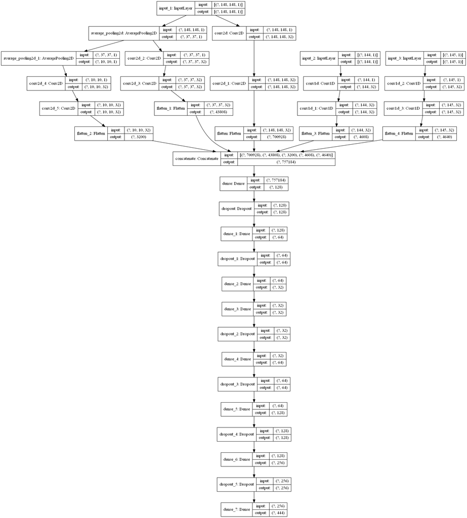

## Losses

```python
m1_loss = pd.read_pickle('losses/train_hist_dist_cnn_funnel_small_new_pooling_latent_drop.pkl')
m2_loss = pd.read_pickle('losses/train_hist_dist_cnn_funnel_small_convo.pkl')
m3_loss = pd.read_pickle('losses/train_hist_new_pooling_deep_latent.pkl')
m4_loss = pd.read_pickle('losses/train_hist_dist_cnn_funnel_small_convo_dec.pkl')
m5_loss = pd.read_pickle('losses/train_hist_dist_cnn_no_pool-6l.pkl')
m6_loss = pd.read_pickle('losses/train_hist_dist_cnn.pkl')
m7_loss = pd.read_pickle('losses/train_hist_dense.pkl')
m8_loss = pd.read_pickle('../3-multi/train_funnel_multi_new_pool.pkl')

losses = [m1_loss, m2_loss, m3_loss, m4_loss, m5_loss, m6_loss, m7_loss, m8_loss]
```

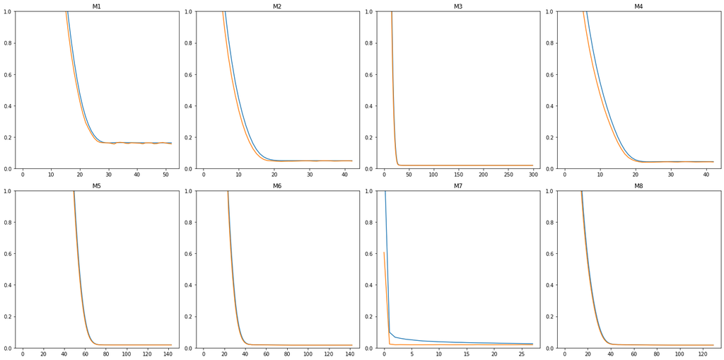

```python
plt.figure()
fig, ax = plt.subplots(2, 4, figsize=(20,10))

k=0
titles=['M1', 'M2', 'M3', 'M4', 'M5', 'M6', 'M7', 'M8']

for i in range(2):
    for j in range(4):
        ax[i,j].plot(losses[k])
        ax[i,j].set_title(titles[k])
        ax[i,j].set_ylim(0, 1)
        k+=1

plt.tight_layout()
plt.show()
```

### Analysis of Loss curves

# Latent space analysis

```python
print('Prepare data')
def prepare_data_for_fitting(traj_n, feat):
    ftraj = {}
    for key in range(traj_n):
        value = np.load('../1-featurize/'+str(key)+'_'+feat+'_scaled.npy')
        ftraj[key] = value
    return ftraj

ftraj_dist = prepare_data_for_fitting(12, 'contacts_squared')
values_dist = np.array(list(ftraj_dist.values()))
values_dist = values_dist.reshape(values_dist.shape[0]*values_dist.shape[1], values_dist.shape[2], values_dist.shape[3])
```

```
Prepare data
```

```python
ftraj_dist_dense = prepare_data_for_fitting(12, 'contacts')
values_dist_dense = np.array(list(ftraj_dist_dense.values()))
values_dist_dense = values_dist_dense.reshape(values_dist_dense.shape[0]*values_dist_dense.shape[1], values_dist_dense.shape[2])
```

[output not shown]

```python
ftraj_angls = prepare_data_for_fitting(12, 'angles')
values_angls = np.array(list(ftraj_angls.values()))
values_angls = values_angls.reshape(values_angls.shape[0]*values_angls.shape[1], values_angls.shape[2])
```

```python
ftraj_dihe = prepare_data_for_fitting(12, 'dihedrals')
values_dihe = np.array(list(ftraj_dihe.values()))
values_dihe = values_dihe.reshape(values_dihe.shape[0]*values_dihe.shape[1], values_dihe.shape[2])
```

## Here we are loading the encoders

```python
# Load pre-trained encoders to project conformational latent spaces
M1 = keras.models.load_model('weights/encoder_dist_cnn_funnel_small_new_pooling_latent_drop.h5')
M2 = keras.models.load_model('weights/encoder_dist_cnn_funnel_small_convo.h5')
M3 = keras.models.load_model('weights/encoder_new_pooling_deep_latent.h5')
M4 = keras.models.load_model('weights/encoder_dist_cnn_funnel_small_convo_dec.h5')
M5 = keras.models.load_model('weights/encoder_dist_cnn_no_pool-6l.h5')
M6 = keras.models.load_model('weights/encoder_dist_cnn.h5')
M7 = keras.models.load_model('weights/encoder_dense.h5')
M8 = keras.models.load_model('../3-multi/encoder_funnel_multi_new_pool.h5')
```

[output not shown]

### How we are using the model to project the latent space

The goal of this study was to obtain and visualize a good conformational space for the simulation data we obtained while utilizing a dimensionality reduction method. Similarly to other dimensionality reduction methods, we transform the data we have fitted. For this reason we are visualizing the entire simulations.

Note: We want to analyze the data used for training, not make predctions from this data.

```python
m1_latent = M1.predict(values_dist)
m2_latent = M2.predict(values_dist)
m3_latent = M3.predict(values_dist)
m4_latent = M4.predict(values_dist)
m5_latent = M5.predict(values_dist)
m6_latent = M6.predict(values_dist)
m7_latent = M7.predict(values_dist_dense)
m8_latent = M8.predict([values_dist, values_dihe, values_angls])
```

```python
values_dihe.shape
```

```
(11880, 144)
```

```python
latents = [m1_latent, m2_latent, m3_latent, m4_latent, m5_latent, m6_latent, m7_latent, m8_latent]
titles=['M1_latent', 'M2_latent', 'M3_latent', 'M4_latent', 'M5_latent', 'M6_latent', 'M7_latent', 'M8_latent']
```

### UMAP

Ultimately we want a good latent space which upon projection can provide information regarding the conformational space in which the protein can exist. The projection is done via UMAP. We use Manhattan distance as it is recognized to be better suited to calculate distances in high dimensional space.

```python
import umap
```

```python
reducer = umap.UMAP(n_neighbors=50, min_dist=0.1, n_components=2, metric='manhattan')
```

```python
projections_umap = []
print('Reducing latent space of:')
for i in range(len(latents)):
    print(titles[i])
    reduced = reducer.fit_transform(latents[i])
    projections_umap.append(reduced)
```

```
Reducing latent space of:
M1_latent
M2_latent
M3_latent
M4_latent
M5_latent
M6_latent
M7_latent
M8_latent
```

```python
# Label frames according to the simulation they belong to

states = []
colors = []
for i in range(11880):
    if i < 2970:
        states.append('vvd_dark_fmc')
        colors.append('tab:orange')
    if i > 2969 and i < 5940:
        states.append('vvd_dark_fmn')
        colors.append('tab:blue')
    if i > 5939 and i < 8910:
        states.append('vvd_light_fmn')
        colors.append('tab:green')
    if i > 8909 and i < 11880:
        states.append('vvd_light_fmc')
        colors.append('tab:red')
```

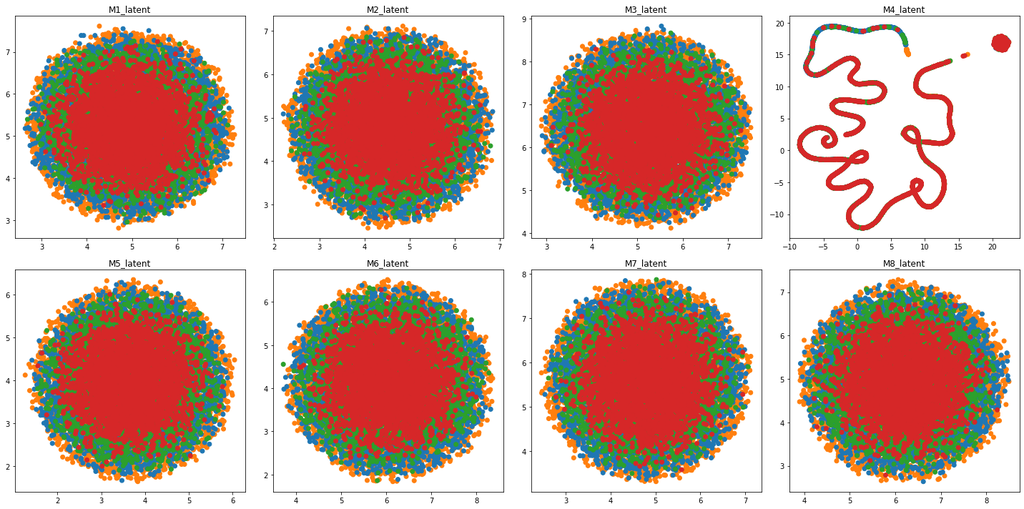

```python
plt.figure()
fig, ax = plt.subplots(2, 4, figsize=(20,10))

k=0
for i in range(2):
    for j in range(4):
        tmp = projections_umap[k]
        ax[i,j].scatter(tmp[:,0], tmp[:,1], color=colors, label=states)
        ax[i,j].set_title(titles[k])
        k+=1
plt.tight_layout()
plt.show()
```

### Analysis of UMAP plots

We observe that most of the projected conformational spaces are spherical (with the exception of ML4, which is the decreased dense model) with all of the protein states overlapping. We expected different states to be well separated in the conformational space. Further analysis on the multi-modal network plus visual analysis show that our models are producing the same output regardless of the input. It seems like the models are learning an optimal output, perhaps an average output, that has small loss regardless of the input.

# Comparing reconstructed protein structure from different models

```python
ML1_reconstruction = np.load('predicted_autoencoder_dist_cnn_funnel_small_new_pooling_latent_drop.npy')
ML2_reconstruction = np.load('predicted_autoencoder_dist_cnn_funnel_small_convo.npy')
ML3_reconstruction = np.load('predicted_autoencoder_new_pooling_deep_latent.npy')
ML4_reconstruction = np.load('predicted_autoencoder_dist_cnn_funnel_small_convo_dec.npy')
ML5_reconstruction = np.load('predicted_autoencoder_dist_cnn_no_pool-6l.npy')
ML6_reconstruction = np.load('predicted_autoencoder_dist_cnn.npy')
ML7_reconstruction = np.load('predicted_autoencoder_dense.npy')
ML8_reconstruction = np.load('predicted_autoencoder_funnel_multi_new_pool.npy')

reconstructions = [ML1_reconstruction, ML2_reconstruction, ML3_reconstruction, ML4_reconstruction, ML5_reconstruction, ML6_reconstruction, ML7_reconstruction, ML8_reconstruction]
```

```python
diffs = np.empty((len(reconstructions), len(reconstructions)))
for i in range(len(reconstructions)):
    for j in range(len(reconstructions)):
        diffs[i,j] = np.sum(abs(reconstructions[i] - reconstructions[j]))
```

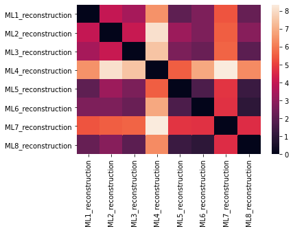

```python
ticks = ['ML1_reconstruction', 'ML2_reconstruction', 'ML3_reconstruction', 'ML4_reconstruction', 'ML5_reconstruction', 'ML6_reconstruction', 'ML7_reconstruction', 'ML8_reconstruction']
sns.heatmap(diffs, xticklabels=ticks, yticklabels=ticks)
plt.show()
```

### Analysis of heatmap

The heatmap is comparing model by model, but that is irrelevant here as each model gives the same output regardless of input. Below we show this with what we expect to be the best model, ML8.

```python
def load_features(filename):
    """Given a .npy file, load the features contained therein into the proper format for processing"""
    features = np.load(filename)
    # Add a trailing dimension
    features = np.expand_dims(features, axis=-1)
    # Add a leading dimentison
    features = np.expand_dims(features, axis=0)
    return features
```

```python
def get_absolute_difference(result1, result2):
    """Give two result sets, compute the absolute difference.  These are assumes to be the results
    of the same model"""
    # Assumes that we have a leading column that is only one element
    return np.absolute(result1-result2)
```

```python
def get_total_absolute_difference(result1, result2):
    """Give two result sets, compute the total absolute difference.  These are assumes to be the results
    of the same model"""
    return np.sum(get_absolute_difference(result1,result2))
```

```python
model = load_model("autoencoder_funnel_multi_new_pool.h5")
```

#### Feature Data

Here, we have three feature sets under evaluation: a matrix of distances, a list of dihedral angles, and a list of regular angles.

```python
distances = load_features('distances_input.npy')
distances.shape
```

```
(1, 148, 148, 1)
```

```python
dihedrals = load_features("dihedrals_input.npy")
dihedrals.shape
```

```
(1, 144, 1)
```

```python
angles = load_features("angles_input.npy")
angles.shape
```

```
(1, 145, 1)
```

#### Model Result

When we run them through the model, we get a matrix containing the 3D (x, y, z coordinates) conformational space, all of which are non-negative real numbers.

```python
predicetd_result = model.predict([distances, dihedrals, angles])
# Drop the first column as it will be 1 as we only prediceted on one data set
predicetd_result = predicetd_result[0]
predicetd_result.shape
```

```
(444,)
```

```python
# First 10 elements as an example
predicetd_result[0:10]
```

```
array([3.101978 , 4.032804 , 2.6637158, 3.141365 , 4.0304585, 2.6546366,
       3.1479156, 3.953377 , 2.645181 , 3.2198904], dtype=float32)
```

#### Real Result

This is obtained from running molecular dynamics (MD) simulations.

```python
true_result = np.load("1_traj_sup_pos_frame.npy")
flattened = []
for index in range(true_result.shape[0]):
    flattened.append(true_result[index][0])
    flattened.append(true_result[index][1])
    flattened.append(true_result[index][2])
true_result = np.asarray(flattened)
true_result.shape
```

```
(444,)
```

```python
# First 10 elements as an example
true_result[0:10]
```

```
array([2.8199978, 4.193088 , 2.0037196, 3.1910975, 4.121811 , 2.0154939,
       3.4132445, 3.8098083, 1.992723 , 3.5784125], dtype=float32)
```

### Distances

```python
length = len(distances[0])

# Storage for the resulting difference between the real and perturbed input
deltas = np.empty((length, length))
deltas[:] = np.nan

# This is assumes to be a square matrix.  Recall that we added empty
# leading and training columns for proper processing of the model.  Also
# note that it contains three spacial distances (x,y,z) and there are
# instances, e.g. on the diagonal that the distance is zero.  Finally, this
# is a symmetric matrix
for x in range(length):
    for y in range(length):
        if distances[0][x][y] == 0:
            # Perturbing this will have no effect
            deltas[x][y] = 0
        elif np.isnan(deltas[x][y]):
            # Avoid processing twice
            distances_copy = np.copy(distances)
            distances_copy[0][x][y] *= 100
            temp_result = model.predict([distances_copy, dihedrals, angles])
            delta = get_total_absolute_difference(temp_result[0], result)
            deltas[x][y] = delta
            deltas[y][x] = delta
    #print("Processed row {}".format(x))
```

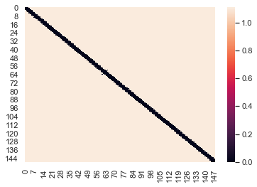

```python
ax = sns.heatmap(deltas)
```

### Dihedrals

```python
length = len(dihedrals[0])

# Stroage for the resulting difference between the real and perturbed input
deltas = np.empty(length)
deltas[:] = np.nan

for x in range(length):
    dihedrals_copy = np.copy(dihedrals)
    dihedrals_copy[0][x] *= 100
    temp_result = model.predict([distances, dihedrals_copy, angles])
    delta = get_total_absolute_difference(temp_result[0], result)
    deltas[x]= delta
    #print("Processed row {}".format(x))
```

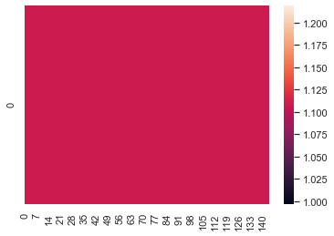

```python
ax = sns.heatmap([deltas])
```

### Regular Angles

```python
length = len(angles[0])

# Stroage for the resulting difference between the real and perturbed input
deltas = np.empty(length)
deltas[:] = np.nan

for x in range(length):
    angles_copy = np.copy(angles)
    angles_copy[0][x] *= 100
    temp_result = model.predict([distances, dihedrals, angles_copy])
    delta = get_total_absolute_difference(temp_result[0], result)
    deltas[x]= delta
    #print("Processed row {}".format(x))
```

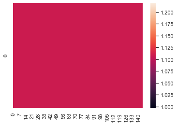

```python
ax = sns.heatmap([deltas])
```

### Interpretation (distances, dihedral angles, and regular angles)

In all of the cases above, the perturbation of the input has no effect on the model's output. In this case, there is a 1.11 nm distance difference between the simulated data and the predicted data. This is clearly shown not to change in the first heatmap. Likewise, in the second and third heatmap which is looking at the two angles. In each case, each datum was increased 100-fold which, based on domain expertise, should have caused some changes in the output. To confirm this is the case, we input random numbers into the model for all data points with the same results. **In effect, the model makes the same prediction regargless of input**.

## Visualize the Difference between the True and Predicted Results

Here, we look at the absolute difference of each data point.

### Building the molecule--visual representation

```python
def build_molecule(mol, i, name):

    #Shape numpy output file into n x3 where n is the number of residues
    #Save it as xyz file

    mol = mol.reshape(int(mol.shape[1]/3), 3)
    f = open('predicted_structures/'+model+'_'+str(i)+'_predicted.xyz', 'w')
    f.write(str(len(mol))+'\n')
    f.write('reconstructed molecule \n')

    for i in mol:
        x, y, z = str(i[0]*10), str(i[1]*10), str(i[2]*10)
        f.write('C       '+x+'      '+y+'      '+z+'\n')
    f.close()


def create_pdb(predicted, i, model_name):

    # the folowing extract the information of the atoms used in the analysis (alpha carbons) needed to build a PDB (protein data bank) format file
    ref = md.load('../0-trajs/traj_2.dcd', top='../0-trajs/traj_2.psf')
    topo = ref.topology
    indx = topo.select('name CA')
    traj = ref.atom_slice(indx)
    topo = traj.topology

    #Extract pdf format for visualizrion
    build_molecule(predicted, i, model_name)

    # from xyz to protein data bank format using the topology information from above
    predicted_xyz = md.load_xyz('predicted_structures/'+model+'_'+str(i)+'_predicted.xyz', top=topo)
    predicted_xyz.save_pdb('predicted_structures/'+model+'_'+str(i)+'_predicted.pdb')
```

The pdbs obtained are used for the visualization of the structures below. From the overlap of these frames we see that the overall prediction is identical. Few networks fail in placing one atom each, this error is localized as well in the same region. These analyses show that despite the overall changes in the networks we obtain the same results and suffer from the same problems.

[figure not shown]

### Quantitative Representation (using the M8 model)

The result of this model is a 3D represntation of the conformational space, and one may qualitatively view it next to the the "true" structure which was generated through simulation. In an effort to quantitatively analyze these results, we look at the magnitude of the difference of each (x,y,z coordinates), and then use domain expertise to interpret that difference.

```python
# This is assumes that both lists are the same length.  Technically, it is a list
# of a sequence of x, y, z coordinates
delta = get_absolute_difference(true_result, predicetd_result)
df = pd.DataFrame(columns = ['Atom', 'Delta', "Direction"])
atom = 0
for x_val, y_val, z_val in zip(*[iter(delta)]*3):
    atom += 1
    df = df.append({'Atom':atom, 'Delta':x_val, 'Direction':'x'}, ignore_index = True)
    df = df.append({'Atom':atom, 'Delta':y_val, 'Direction':'y'}, ignore_index = True)
    df = df.append({'Atom':atom, 'Delta':z_val, 'Direction':'z'}, ignore_index = True)
```

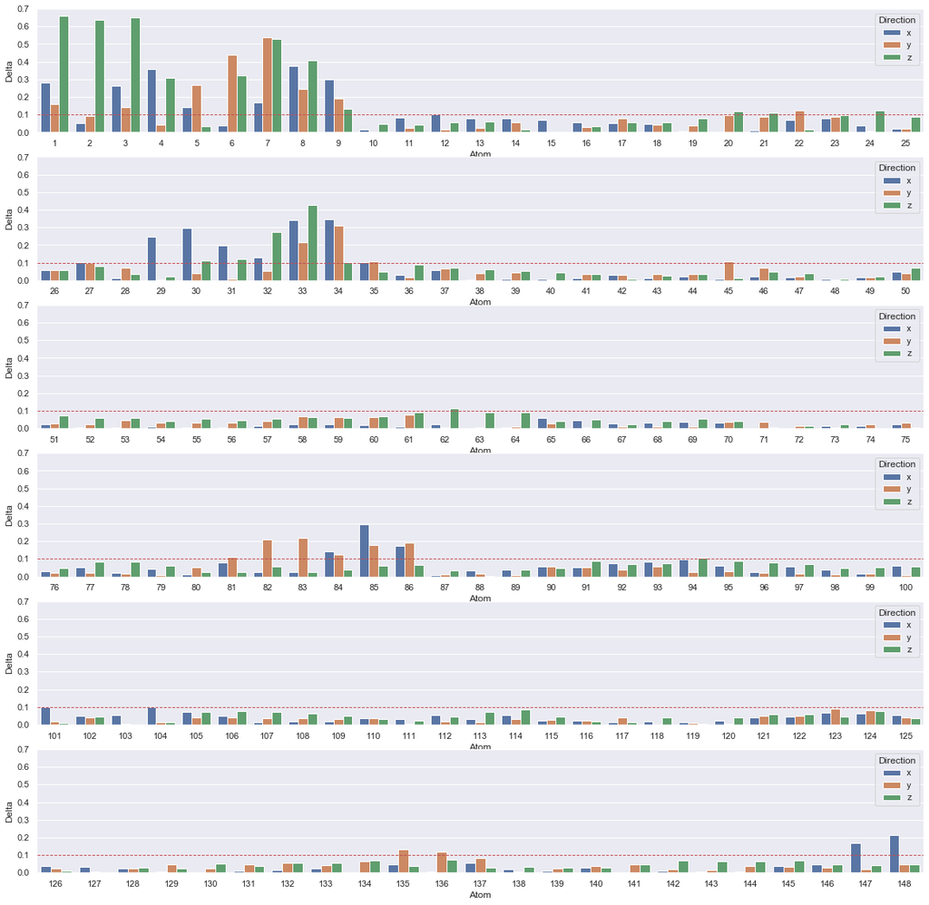

```python
limit = round(np.max(delta)+.05, 1)
sns.set()
fig, axs = plt.subplots(nrows=6, ncols=1,figsize=(20,20))
plt.sca(axs[0])
plt.ylim(0, limit)
sns.barplot(x = "Atom", y = "Delta", hue = "Direction", data=df[df['Atom']<=25])
plt.axhline(y=0.1, xmin=-1, xmax=1, color='r', linestyle='--', lw=1)
plt.sca(axs[1])
plt.ylim(0, limit)
sns.barplot(x = "Atom", y = "Delta", hue = "Direction", data=df[(df['Atom']>25) & (df['Atom']<=50)])
plt.axhline(y=0.1, xmin=-1, xmax=1, color='r', linestyle='--', lw=1)
plt.sca(axs[2])
plt.ylim(0, limit)
sns.barplot(x = "Atom", y = "Delta", hue = "Direction", data=df[(df['Atom']>50) & (df['Atom']<=75)])
plt.axhline(y=0.1, xmin=-1, xmax=1, color='r', linestyle='--', lw=1)
plt.sca(axs[3])
plt.ylim(0, limit)
sns.barplot(x = "Atom", y = "Delta", hue = "Direction", data=df[(df['Atom']>75) & (df['Atom']<=100)])
plt.axhline(y=0.1, xmin=-1, xmax=1, color='r', linestyle='--', lw=1)
plt.sca(axs[4])
plt.ylim(0, limit)
sns.barplot(x = "Atom", y = "Delta", hue = "Direction", data=df[(df['Atom']>100) & (df['Atom']<=125)])
plt.axhline(y=0.1, xmin=-1, xmax=1, color='r', linestyle='--', lw=1)
plt.sca(axs[5])
plt.ylim(0, limit)
sns.barplot(x = "Atom", y = "Delta", hue = "Direction", data=df[(df['Atom']>125) & (df['Atom']<=150)])
plt.axhline(y=0.1, xmin=-1, xmax=1, color='r', linestyle='--', lw=1)
plt.show()
```

```python
describe(delta)
```

```
DescribeResult(nobs=444, minmax=(9.75132e-05, 0.6599963), mean=0.064355046, variance=0.008058039, skewness=3.714977741241455, kurtosis=16.735709057817697)
```

### Interpretation

As may be seen in the above charts, the absolute difference between the simulated structure and reconstructred structure is very similar, in most cases less than 0.1 nanometer. There are a few peaks which account for the anomolies visible in the rendered image of the reonstructed protein.

# Conclusion

We took molecular features (distances, dihedral angles, and regular angles), we convolved them, and fed them into the latent space. Then the reconstructed protein matches the simulated protein pretty closely. We believe that model 8 (M8) is the best model. However, all models trained to return the same result regardless of input. Therefore, they are not currently generalizable.